# Prediction of academic achievement in adolescents from teacher reports of inattention in childhood - a pattern classification study

AJ Lundervold, T Bø, A Lundervold

```r
~GitHub/inattention-population/code/inattention-populationsample-rf.Rmd
```

Organization of the data and the analysis:

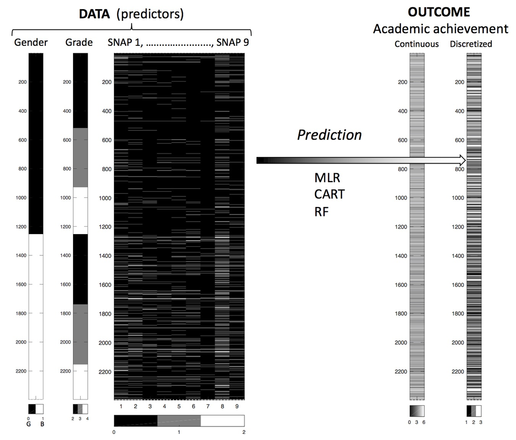

### Data preparation

Builds on processing in *~GitHub/inattention-population/code/inattention-populationsample-data-prep.Rmd*

```r
D3 <- read.csv(file = "../data/inattention_nomiss_2397x12_snap_is_0_1_2.csv")
C <- read.csv(file = "../data/inattention_nomiss_2397x12_snap_is_0_1_2_outcome_is_L_M_H.csv")
D <- read.csv(file = "../data/inattention_nomiss_2397x12_snap_is_N_S_C_outcome_is_L_M_H.csv")
E <- read.csv(file = "../data/inattention_nomiss_2397x12_snap_is_0_1_2_outcome_is_0_1_2.csv")
str(D3)
```

```
'data.frame':   2397 obs. of  12 variables:
 $ gender: int  1 1 1 1 1 1 1 1 1 1 ...
 $ grade : int  2 2 2 2 2 2 2 2 2 2 ...
 $ snap1 : int  1 1 1 1 1 1 1 1 1 1 ...
 $ snap2 : int  1 1 1 1 1 1 1 1 1 1 ...
 $ snap3 : int  1 2 1 1 1 1 1 1 1 1 ...
 $ snap4 : int  1 1 1 1 1 1 1 1 1 1 ...
 $ snap5 : int  1 1 1 1 1 1 1 1 1 1 ...
 $ snap6 : int  1 1 1 1 1 1 1 1 1 1 ...
 $ snap7 : int  1 1 1 1 1 1 1 1 1 1 ...
 $ snap8 : int  1 1 1 1 1 1 1 1 2 1 ...
 $ snap9 : int  1 1 1 1 1 1 1 1 1 1 ...
 $ ave   : num  4.67 3.67 4.14 4.11 4.3 ...
```

```r
head(D3)
```

|  | gender | grade | snap1 | snap2 | snap3 | snap4 | snap5 | snap6 | snap7 | snap8 | snap9 | ave |
| --- | --- | --- | --- | --- | --- | --- | --- | --- | --- | --- | --- | --- |
| 1 | 1 | 2 | 1 | 1 | 1 | 1 | 1 | 1 | 1 | 1 | 1 | 4.666667 |
| 2 | 1 | 2 | 1 | 1 | 2 | 1 | 1 | 1 | 1 | 1 | 1 | 3.666667 |
| 3 | 1 | 2 | 1 | 1 | 1 | 1 | 1 | 1 | 1 | 1 | 1 | 4.142857 |
| 4 | 1 | 2 | 1 | 1 | 1 | 1 | 1 | 1 | 1 | 1 | 1 | 4.111111 |
| 5 | 1 | 2 | 1 | 1 | 1 | 1 | 1 | 1 | 1 | 1 | 1 | 4.300000 |
| 6 | 1 | 2 | 1 | 1 | 1 | 1 | 1 | 1 | 1 | 1 | 1 | 3.888889 |

```r
str(C)
```

```
'data.frame':   2397 obs. of  12 variables:
 $ gender    : int  1 1 1 1 1 1 1 1 1 1 ...
 $ grade     : int  2 2 2 2 2 2 2 2 2 2 ...
 $ snap1     : int  1 1 1 1 1 1 1 1 1 1 ...
 $ snap2     : int  1 1 1 1 1 1 1 1 1 1 ...
 $ snap3     : int  1 2 1 1 1 1 1 1 1 1 ...
 $ snap4     : int  1 1 1 1 1 1 1 1 1 1 ...
 $ snap5     : int  1 1 1 1 1 1 1 1 1 1 ...
 $ snap6     : int  1 1 1 1 1 1 1 1 1 1 ...
 $ snap7     : int  1 1 1 1 1 1 1 1 1 1 ...
 $ snap8     : int  1 1 1 1 1 1 1 1 2 1 ...
 $ snap9     : int  1 1 1 1 1 1 1 1 1 1 ...
 $ averBinned: Factor w/ 3 levels "H","L","M": 1 2 3 3 3 3 2 3 1 3 ...
```

```r
head(C)
```

|  | gender | grade | snap1 | snap2 | snap3 | snap4 | snap5 | snap6 | snap7 | snap8 | snap9 | averBinned |
| --- | --- | --- | --- | --- | --- | --- | --- | --- | --- | --- | --- | --- |
| 1 | 1 | 2 | 1 | 1 | 1 | 1 | 1 | 1 | 1 | 1 | 1 | H |
| 2 | 1 | 2 | 1 | 1 | 2 | 1 | 1 | 1 | 1 | 1 | 1 | L |
| 3 | 1 | 2 | 1 | 1 | 1 | 1 | 1 | 1 | 1 | 1 | 1 | M |
| 4 | 1 | 2 | 1 | 1 | 1 | 1 | 1 | 1 | 1 | 1 | 1 | M |
| 5 | 1 | 2 | 1 | 1 | 1 | 1 | 1 | 1 | 1 | 1 | 1 | M |
| 6 | 1 | 2 | 1 | 1 | 1 | 1 | 1 | 1 | 1 | 1 | 1 | M |

```r
str(D)
```

```
'data.frame':   2397 obs. of  12 variables:
 $ gender    : Factor w/ 2 levels "B","G": 1 1 1 1 1 1 1 1 1 1 ...
 $ grade     : Factor w/ 3 levels "2nd","3rd","4th": 1 1 1 1 1 1 1 1 1 1 ...
 $ snap1     : Factor w/ 3 levels "C","N","S": 3 3 3 3 3 3 3 3 3 3 ...
 $ snap2     : Factor w/ 3 levels "C","N","S": 3 3 3 3 3 3 3 3 3 3 ...
 $ snap3     : Factor w/ 3 levels "C","N","S": 3 1 3 3 3 3 3 3 3 3 ...
 $ snap4     : Factor w/ 3 levels "C","N","S": 3 3 3 3 3 3 3 3 3 3 ...
 $ snap5     : Factor w/ 3 levels "C","N","S": 3 3 3 3 3 3 3 3 3 3 ...
 $ snap6     : Factor w/ 3 levels "C","N","S": 3 3 3 3 3 3 3 3 3 3 ...
 $ snap7     : Factor w/ 3 levels "C","N","S": 3 3 3 3 3 3 3 3 3 3 ...
 $ snap8     : Factor w/ 3 levels "C","N","S": 3 3 3 3 3 3 3 3 1 3 ...
 $ snap9     : Factor w/ 3 levels "C","N","S": 3 3 3 3 3 3 3 3 3 3 ...
 $ averBinned: Factor w/ 3 levels "H","L","M": 1 2 3 3 3 3 2 3 1 3 ...
```

```r
head(D)
```

|  | gender | grade | snap1 | snap2 | snap3 | snap4 | snap5 | snap6 | snap7 | snap8 | snap9 | averBinned |
| --- | --- | --- | --- | --- | --- | --- | --- | --- | --- | --- | --- | --- |
| 1 | B | 2nd | S | S | S | S | S | S | S | S | S | H |
| 2 | B | 2nd | S | S | C | S | S | S | S | S | S | L |
| 3 | B | 2nd | S | S | S | S | S | S | S | S | S | M |
| 4 | B | 2nd | S | S | S | S | S | S | S | S | S | M |
| 5 | B | 2nd | S | S | S | S | S | S | S | S | S | M |
| 6 | B | 2nd | S | S | S | S | S | S | S | S | S | M |

```r
str(E)
```

```
'data.frame':   2397 obs. of  12 variables:
 $ gender    : int  1 1 1 1 1 1 1 1 1 1 ...
 $ grade     : int  2 2 2 2 2 2 2 2 2 2 ...
 $ snap1     : int  1 1 1 1 1 1 1 1 1 1 ...
 $ snap2     : int  1 1 1 1 1 1 1 1 1 1 ...
 $ snap3     : int  1 2 1 1 1 1 1 1 1 1 ...
 $ snap4     : int  1 1 1 1 1 1 1 1 1 1 ...
 $ snap5     : int  1 1 1 1 1 1 1 1 1 1 ...
 $ snap6     : int  1 1 1 1 1 1 1 1 1 1 ...
 $ snap7     : int  1 1 1 1 1 1 1 1 1 1 ...
 $ snap8     : int  1 1 1 1 1 1 1 1 2 1 ...
 $ snap9     : int  1 1 1 1 1 1 1 1 1 1 ...
 $ averBinned: int  2 0 1 1 1 1 0 1 2 1 ...
```

```r
head(E)
```

|  | gender | grade | snap1 | snap2 | snap3 | snap4 | snap5 | snap6 | snap7 | snap8 | snap9 | averBinned |
| --- | --- | --- | --- | --- | --- | --- | --- | --- | --- | --- | --- | --- |
| 1 | 1 | 2 | 1 | 1 | 1 | 1 | 1 | 1 | 1 | 1 | 1 | 2 |
| 2 | 1 | 2 | 1 | 1 | 2 | 1 | 1 | 1 | 1 | 1 | 1 | 0 |
| 3 | 1 | 2 | 1 | 1 | 1 | 1 | 1 | 1 | 1 | 1 | 1 | 1 |
| 4 | 1 | 2 | 1 | 1 | 1 | 1 | 1 | 1 | 1 | 1 | 1 | 1 |
| 5 | 1 | 2 | 1 | 1 | 1 | 1 | 1 | 1 | 1 | 1 | 1 | 1 |
| 6 | 1 | 2 | 1 | 1 | 1 | 1 | 1 | 1 | 1 | 1 | 1 | 1 |

### Random Forest for SNAP inattention data

Random forests are very good in that it is an ensemble learning method used for classification and regression. It uses multiple models for better performance that just using a single tree model. In addition because many sample are selected in the process a measure of variable importance can be obtain and this approach can be used for model selection and can be particularly useful when forward/backward stepwise selection is not appropriate and when working with an extremely high number of candidate variables that need to be reduced.

```r
library(randomForest)
E$averBinnedF = as.factor(E$averBinned)  # To perform clasification and not regression
E <- subset(E, select = -c(averBinned))
frmla = averBinnedF ~ gender + grade + snap1 + snap2 + snap3 +
    snap4 + snap5 + snap6 + snap7 + snap8 + snap9
fit.Erf = randomForest(frmla, data=E)
print(fit.Erf)
```

```
Call:
 randomForest(formula = frmla, data = E)
               Type of random forest: classification
                     Number of trees: 500
No. of variables tried at each split: 3

        OOB estimate of  error rate: 56.2%
Confusion matrix:
    0   1   2 class.error
0 253 239 287   0.6752246
1 147 273 398   0.6662592
2  70 206 524   0.3450000
```

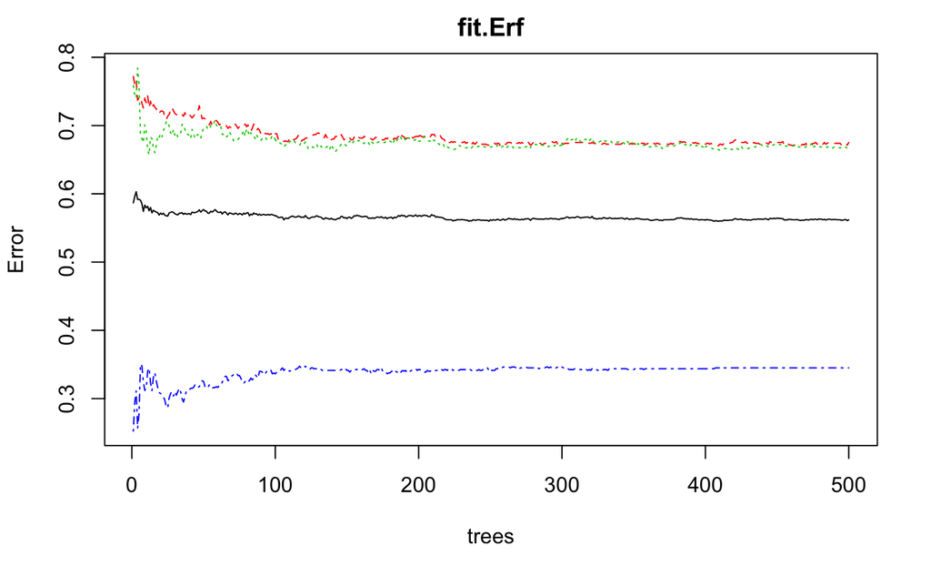

```r
plot(fit.Erf)
```

#### Extract variable importance measure:

Here are the definitions of the variable importance measures. The first measure is computed from permuting OOB data: For each tree, the prediction error on the out-of-bag portion of the data is recorded (error rate for classification, MSE for regression). Then the same is done after permuting each predictor variable. The difference between the two are then averaged over all trees, and normalized by the standard deviation of the differences. If the standard deviation of the differences is equal to 0 for a variable, the division is not done (but the average is almost always equal to 0 in that case).

The second measure is the total decrease in node impurities from splitting on the variable, averaged over all trees. For classification, the node impurity is measured by the Gini index. For regression, it is measured by residual sum of squares.

The function being plotted in Partial dependence plot *partialPlot* is defined as:

$$\tilde{f}(x) = \frac{1}{n} ∑_{i=1}^n f(x, x_{iC}),$$

where $x$ is the variable for which partial dependence is sought, and $x_{iC}$ is the other variables in the data. The summand is the predicted regression function for regression, and logits (i.e., log of fraction of votes) for which.class for classification:

$$f(x) = \log p_k(x) - \frac{1}{K} ∑_{j=1}^K \log p_j(x),$$

where $K$ is the number of classes, $k$ is which.class, and $p_j$ is the proportion of votes for class $j$.

```r
importance(fit.Erf)
```

```
       MeanDecreaseGini
gender         21.46649
grade          31.75525
snap1          23.60581
snap2          34.48251
snap3          17.43622
snap4          19.25865
snap5          20.62792
snap6          23.11993
snap7          11.52709
snap8          30.55753
snap9          20.27597
```

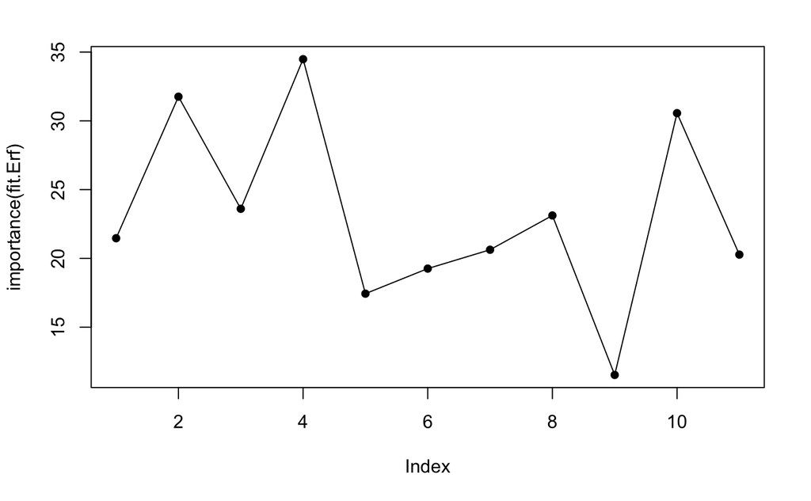

```r
plot(importance(fit.Erf), lty=2, pch=16)
lines(importance(fit.Erf))
```

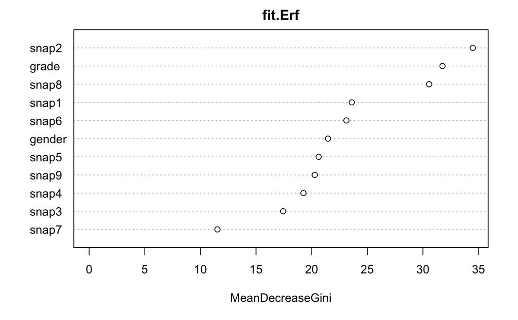

```r
varImpPlot(fit.Erf)
```

#### CORElearn:

This is a great package that contain many different machine learning algorithms and functions. It include trees, forests, naive Bayes, locally weighted regression, among others.

Builds a classification or regression model from the data and formula with given parameters. Classification models available are

- random forests, possibly with local weighing of basic models (parallel execution on several cores),
- decision tree with constructive induction in the inner nodes and/or models in the leaves,
- kNN and weighted kNN with Gaussian kernel,
- naive Bayesian classifier.

Regression models:

- regression trees with constructive induction in the inner nodes and/or models in the leaves,
- linear models with pruning techniques,
- locally weighted regression,
- kNN and weighted kNN with Gaussian kernel.

```r
library(CORElearn)
## Random Forests
frmla = averBinnedF ~ gender + grade + snap1 + snap2 + snap3 +
    snap4 + snap5 + snap6 + snap7 + snap8 + snap9
fit.E.rand.forest = CoreModel(frmla, data=E, model="rf", selectionEstimator="MDL", minNodeWeightRF=5, rfNoTrees=500)
```

```
NAs introduced by coercion
```

```r
print(fit.E.rand.forest)
```

```
$modelID
[1] 0

$class.lev
[1] "0" "1" "2"

$model
[1] "rf"

$formula
averBinnedF ~ gender + grade + snap1 + snap2 + snap3 + snap4 +
    snap5 + snap6 + snap7 + snap8 + snap9
<environment: 0x11ae43238>

$noClasses
[1] 3

$priorClassProb

        0         1         2
0.3249896 0.3412599 0.3337505

$avgTrainPrediction
[1] 0

$noNumeric
[1] 11

$noDiscrete
[1] 1

$discAttrNames
[1] "averBinnedF"

$discValNames
$discValNames[[1]]
[1] "0" "1" "2"


$numAttrNames
 [1] "gender" "grade"  "snap1"  "snap2"  "snap3"  "snap4"  "snap5"  "snap6"  "snap7"  "snap8"  "snap9"

$discmap
[1] 1

$nummap
 [1]  2  3  4  5  6  7  8  9 10 11 12

$skipmap
integer(0)

attr(,"class")
[1] "CoreModel"
```

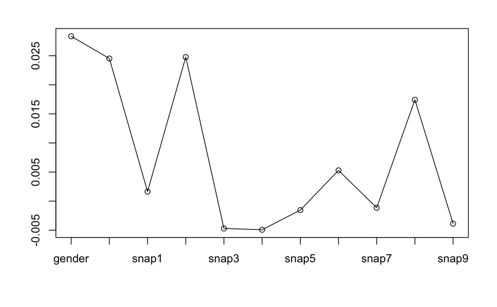

```r
plot(fit.E.rand.forest)
```

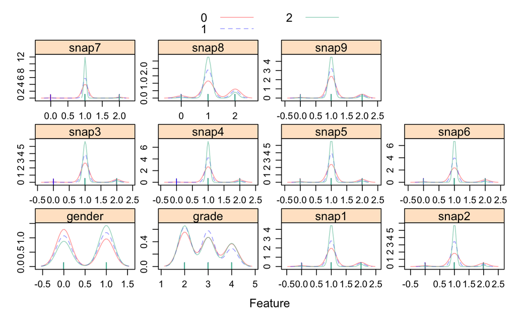

```r
library(caret)
# Feature density plots
library(AppliedPredictiveModeling)
transparentTheme(trans = 0.4)
featurePlot(x = E[, 1:11],
            y = E$averBinnedF,
            plot = "density",
            scales = list(x = list(relation="free"),
                          y = list(relation="free")),
            pch = "|",
            adjust = 1.5,
            layout = c(4,3),
            ## Add a key at the top
            auto.key = list(columns = 2))
```

### Using the CARET package

The caret package (short for classification and regression training) contains functions to streamline the model training process for complex regression and classification problems. The package utilizes a number of R packages but tries not to load them all at package start-up. The package “suggests” field includes 27 packages. caret loads packages as needed and assumes that they are installed.

```r
# Functions and Datasets from J. Fox and S. Weisberg, An R Companion to Applied Regression,
# Second Edition, Sage, 2011.
library(car)
# Keep 75 (70) % of the observations for training the classifier,
# and 25 (30) % of the sample for performance evaluation (e.g. confusion matrix)
set.seed(998)
trainIndex <- createDataPartition(E$averBinnedF, p=.75, list=F)
# trainIndex <- createDataPartition(data$class, p=.70, list=F)
E.train <- E[trainIndex, ]
E.test <- E[-trainIndex, ]
# Check the random sample used for training
head(trainIndex)
```

```
     Resample1
[1,]         2
[2,]         3
[3,]         4
[4,]         5
[5,]         6
[6,]         7
```

```r
# The function trainControl can be used to specifiy the type of resampling in the training set
fitControl <- trainControl(   ## 10-fold CV [cross validation]
  method = "repeatedcv",
  number = 10,
  ## repeated ten times
  repeats = 10)
# Preprocessing (normalization) of training data
# Check: https://github.com/topepo/caret/issues/160
pp.E.train <- preProcess(E.train, method = c("center", "scale"))
pp.E.train <- predict.preProcess(pp.E.train, E.train)
```

```
Error: could not find function "predict.preProcess"
```

Train the RF or ANN model on the training set (caret package) check: to http://cran.r-project.org/web/packages/nnet/nnet.pdf, and http://topepo.github.io/caret/training.html The function train() sets up a grid of tuning parameters for a number of classification and regression routines, fits each model and calculates a resampling based performance measure. method - a string specifying which classification or regression model to use see http://topepo.github.io/caret/bytag.html and https://www.byclb.com/TR/Tutorials/neural_networks/ch10_1.htm !!

```r
# Random Forest classifier  cf. help(randomForest)
# method = 'rf'
# Type: Classification, Regression
# Tuning Parameters: mtry (number of variables randomly sampled as candidates at each split)
# For these caret models, train can automatically create a grid of tuning parameters.
# By default, if p is the number of tuning parameters, the grid size is 3^p.
# For rf we explore mtry
my.rf.grid <- expand.grid(.mtry = c(1, 2, 3))
E.rf.fit <- train(averBinnedF ~ . , data = E.train,
                       method = "rf",
                       maxit = 1000,
                       trControl = fitControl,
                       tuneGrid = my.rf.grid,
                       trace = FALSE)
print(E.rf.fit$finalModel$problemType)
```

```
[1] "Classification"
```

```r
print(E.rf.fit$finalModel$n)
```

```
[1] 500
```

```r
print(E.rf.fit$finalModel$call)
```

```
randomForest(x = x, y = y, mtry = param$mtry, maxit = 1000, trace = FALSE)
```

```r
print(E.rf.fit$finalModel)
```

```
Call:
 randomForest(x = x, y = y, mtry = param$mtry, maxit = 1000, trace = FALSE)
               Type of random forest: classification
                     Number of trees: 500
No. of variables tried at each split: 2

        OOB estimate of  error rate: 55.86%
Confusion matrix:
    0   1   2 class.error
0 202 122 261   0.6547009
1 107 139 368   0.7736156
2  52  95 453   0.2450000
```

```r
print(E.rf.fit)
```

```
Random Forest

1799 samples
  11 predictor
   3 classes: '0', '1', '2'

No pre-processing
Resampling: Cross-Validated (10 fold, repeated 10 times)
Summary of sample sizes: 1620, 1618, 1618, 1620, 1620, 1620, ...
Resampling results across tuning parameters:

  mtry  Accuracy   Kappa
  1     0.4283330  0.1439403
  2     0.4334023  0.1500532
  3     0.4316726  0.1471031

Accuracy was used to select the optimal model using  the largest value.
The final value used for the model was mtry = 2.
```

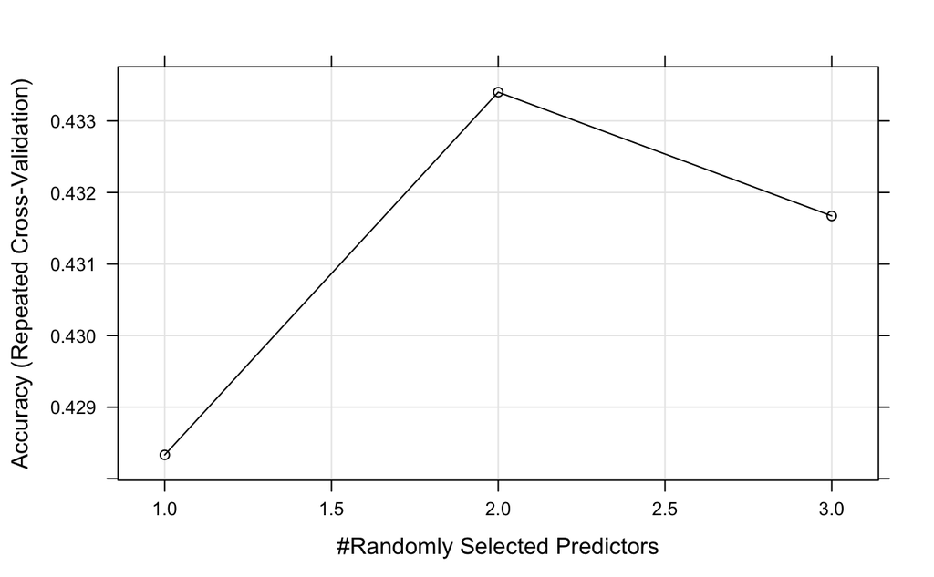

```r
trellis.par.set(caretTheme())
plot(E.rf.fit)
```

```r
# Call predict on the fitted object using the test data set
E.test.rf.predict <- predict(E.rf.fit, newdata = E.test, na.action = na.omit, verbose = TRUE)
print(summary(as.data.frame(E.test.rf.predict)))
```

```
 E.test.rf.predict
 0:115
 1:143
 2:340
```

```r
print(summary(as.data.frame(E.test$averBinnedF)))
```

```
 E.test$averBinnedF
 0:194
 1:204
 2:200
```

```r
# Assess confusion matrix
cm.rf.fit.E.test <- confusionMatrix(E.test.rf.predict, E.test$averBinnedF)
print(cm.rf.fit.E.test)
```

```
Confusion Matrix and Statistics

          Reference
Prediction   0   1   2
         0  58  42  15
         1  52  54  37
         2  84 108 148

Overall Statistics

               Accuracy : 0.4348
                 95% CI : (0.3946, 0.4756)
    No Information Rate : 0.3411
    P-Value [Acc > NIR] : 1.267e-06

                  Kappa : 0.1512
 Mcnemar's Test P-Value : < 2.2e-16

Statistics by Class:

                     Class: 0 Class: 1 Class: 2
Sensitivity           0.29897   0.2647   0.7400
Specificity           0.85891   0.7741   0.5176
Pos Pred Value        0.50435   0.3776   0.4353
Neg Pred Value        0.71843   0.6703   0.7984
Prevalence            0.32441   0.3411   0.3344
Detection Rate        0.09699   0.0903   0.2475
Detection Prevalence  0.19231   0.2391   0.5686
Balanced Accuracy     0.57894   0.5194   0.6288
```

```r
# Call predict on the fitted object using the test data set
E.test.rf.predict <- predict(E.rf.fit, newdata = E.test, na.action = na.omit, verbose = TRUE)
print(summary(as.data.frame(E.test.rf.predict)))
print(summary(as.data.frame(E.test$averBinnedF)))

# Assess confusion matrix
cm.rf.fit.E.test <- confusionMatrix(E.test.rf.predict, E.test$averBinnedF)
print(cm.rf.fit.E.test)
```

[output not shown]

```r
library(plyr)
#mapvalues(E$averBinnedF, from = c("0", "1", "2"), to = c("L", "M", "H"))
#revalue(E$averBinnedF, c("0"="L", "1"="M", "2"="H"))
levels(E$averBinnedF)[levels(E$averBinnedF)=="0"] <- "L"
levels(E$averBinnedF)[levels(E$averBinnedF)=="1"] <- "M"
levels(E$averBinnedF)[levels(E$averBinnedF)=="2"] <- "H"

set.seed(998)
trainIndex <- createDataPartition(E$averBinnedF, p=.75, list=F)
# trainIndex <- createDataPartition(data$class, p=.70, list=F)
E.train <- E[trainIndex, ]
E.test <- E[-trainIndex, ]
```

```r
fitControl <- trainControl(   ## 10-fold CV [cross validation]
  method = "repeatedcv",
  number = 10,
  ## repeated ten times
  repeats = 10,
  classProbs = TRUE)
```

```r
svmFit <- train(averBinnedF ~ . , data = E.train,
                 method = "svmRadial",
                 trControl = fitControl,
                 tuneLength = 8,
                 metric = "ROC")
svmFit
```

[output not shown]

```r
# Call predict on the fitted object using the test data set
E.test.svm.predict <- predict(svmFit, newdata = E.test, na.action = na.omit, verbose = TRUE)
print(summary(as.data.frame(E.test.svm.predict)))
print(summary(as.data.frame(E.test$averBinnedF)))

# Assess confusion matrix
cm.svm.fit.E.test <- confusionMatrix(E.test.svm.predict, E.test$averBinnedF)
print(cm.svm.fit.E.test)
```

[output not shown]